# 03-assignment_-crutchfield

Russell Crutchfield

9/8/2019

## Assignment 3

## Setup for plotting conditional means

We start with a standard set of setup commands. Today we’ll be working with `tidyverse`, as usual, along with a library called `forcats` which helps us to deal with the dreaded factor variables. To handle colors, we’ll need the package `RColorBrewer.`

Next we load in the data.

## Loading Data - load: attrition.Rdata

```r
load("~/Desktop/Fall 2019/Data Science/scripts/attrition.Rdata")
```

## 1. Create a graph that shows the distribution of monthly income.

## create a new ggplot using the attrition data set. Monthly Income will go into the aesthetic is. ## We are creating a histogram. fill will be light blue. The x-axis will be Monthly Income and the ## y-axis represents the individuals count. Binwidth ().

##This is a right-skewed distrobution.

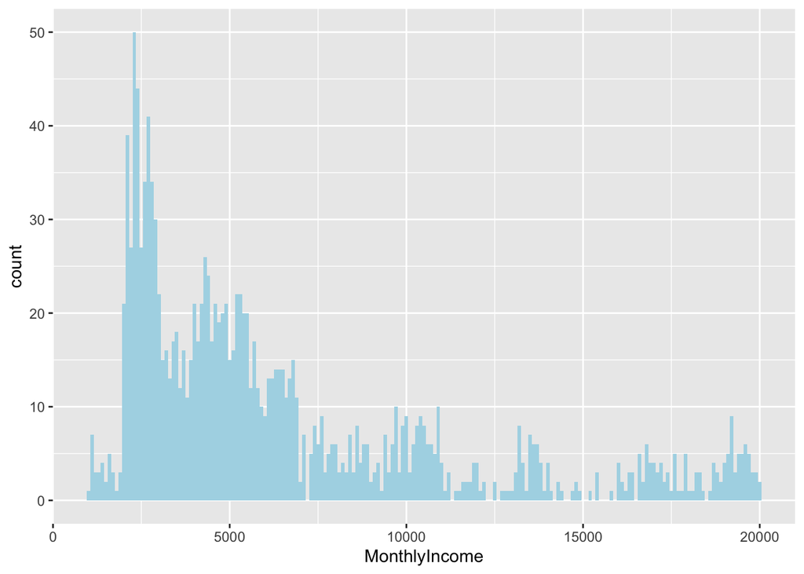

```r
gg<-ggplot(at,aes(x=MonthlyIncome))
gg<-gg+geom_histogram(binwidth = 100,fill="lightblue")
gg
```

## 2. Create a graph that shows the average level of monthly income by field of education.

```r
at_sum<-at%>%
  group_by(EducationField)%>%
  summarize(Monthly_Income_Avg=mean(MonthlyIncome))


at_sum
```

```
## # A tibble: 6 x 2
##   EducationField   Monthly_Income_Avg
##   <chr>                         <dbl>
## 1 Human Resources               7241.
## 2 Life Sciences                 6463.
## 3 Marketing                     7349.
## 4 Medical                       6510.
## 5 Other                         6072.
## 6 Technical Degree              5758.
```

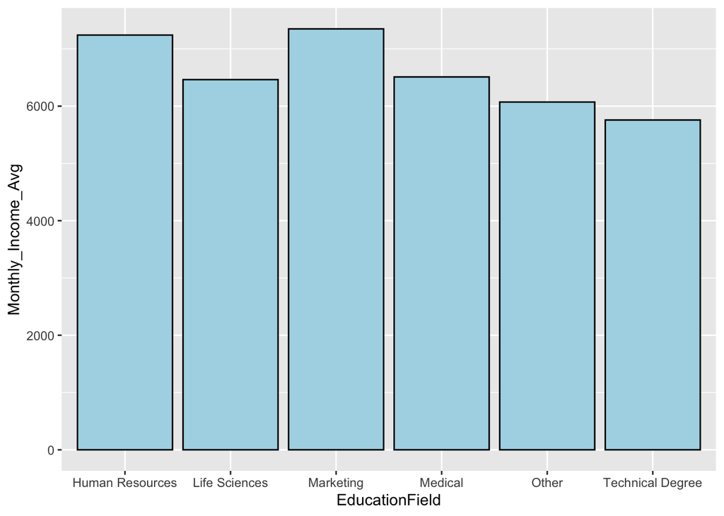

```r
## Bar Plot with aesthetics: mean attrition as height, business travel as cateogry
gg<-ggplot(at_sum,aes(x=EducationField,y=Monthly_Income_Avg))
## Use bar plot geometry, height of bars set by level observed in dataset
gg<-gg+geom_bar(stat="Identity", fill="light blue", color="black")
## Print
gg
```

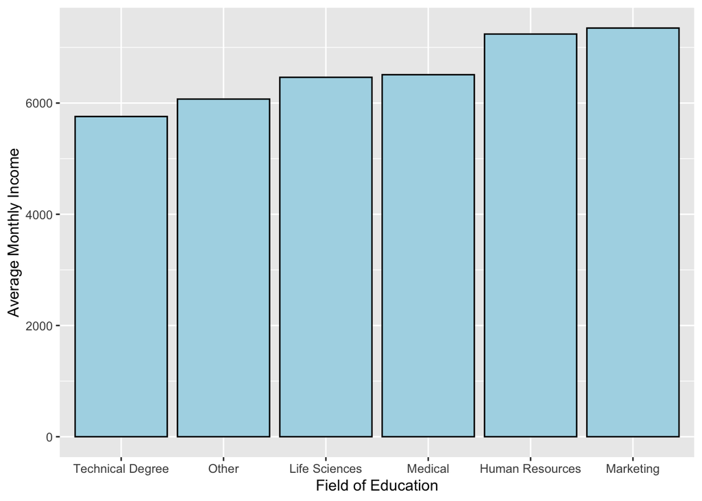

```r
## Same asethetics, but now orderred by level - by Average monthly income, and clean up labels:
gg<-ggplot(at_sum,aes(x=fct_reorder(EducationField,Monthly_Income_Avg),y=Monthly_Income_Avg))

gg<-gg+geom_bar(stat="identity", fill="light blue", color="black")

## Labeling
gg<-gg+xlab("Field of Education")+ylab("Average Monthly Income")
##Print
gg
```

## 3. Create another graph that shows average level of monthly income by field of education and gender.

```r
## Summarize level of monthly income by education AND gender
at_sum<-at%>%
  group_by(EducationField,Gender)%>%
  summarize(Monthly_Income_Avg=mean(MonthlyIncome))

## Get the results
at_sum
```

```
## # A tibble: 12 x 3
## # Groups:   EducationField [6]
##    EducationField   Gender Monthly_Income_Avg
##    <chr>            <chr>               <dbl>
##  1 Human Resources  Female              9568.
##  2 Human Resources  Male                6262.
##  3 Life Sciences    Female              6433.
##  4 Life Sciences    Male                6483.
##  5 Marketing        Female              7586.
##  6 Marketing        Male                7167.
##  7 Medical          Female              6520.
##  8 Medical          Male                6503.
##  9 Other            Female              6114.
## 10 Other            Male                6048.
## 11 Technical Degree Female              7148.
## 12 Technical Degree Male                4855.
```

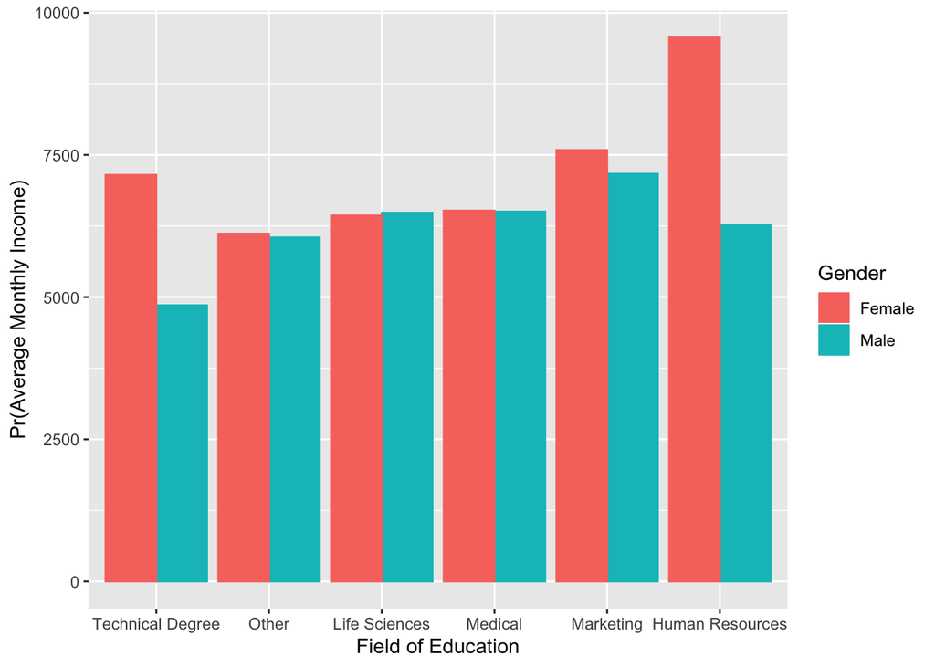

```r
## PLot it using a bar plot
gg<-ggplot(at_sum,aes(x=fct_reorder(EducationField,Monthly_Income_Avg),y=Monthly_Income_Avg,color=Gender))
gg<-gg+geom_bar(stat="identity",aes(fill=Gender),position="dodge")
gg<-gg+ylab("Pr(Average Monthly Income)")+xlab("Field of Education")
gg
```

## 4. Create a graph that shows average levels of monthly income by field of education, gender and job level (scale of 1-5, highest ranked employees are 5)

## ## More Variables: faceting

## We can continue this logic with three variables. Now we’re going to summarize and arrange positions by field of education, gender and job level and then split the graphic by job level.

```r
at_sum<-at%>%
  group_by(EducationField,Gender,JobLevel)%>%
  summarize(Monthly_Income_Avg=mean(MonthlyIncome))%>%
  arrange(-Monthly_Income_Avg)

at_sum
```

```
## # A tibble: 58 x 4
## # Groups:   EducationField, Gender [12]
##    EducationField   Gender JobLevel Monthly_Income_Avg
##    <chr>            <chr>     <int>              <dbl>
##  1 Technical Degree Female        5             19744
##  2 Other            Male          5             19443.
##  3 Human Resources  Male          5             19322
##  4 Medical          Male          5             19251.
##  5 Technical Degree Male          5             19232
##  6 Life Sciences    Male          5             19232.
##  7 Life Sciences    Female        5             19143
##  8 Marketing        Female        5             19101.
##  9 Other            Female        5             19094
## 10 Medical          Female        5             19032.
## # … with 48 more rows
```

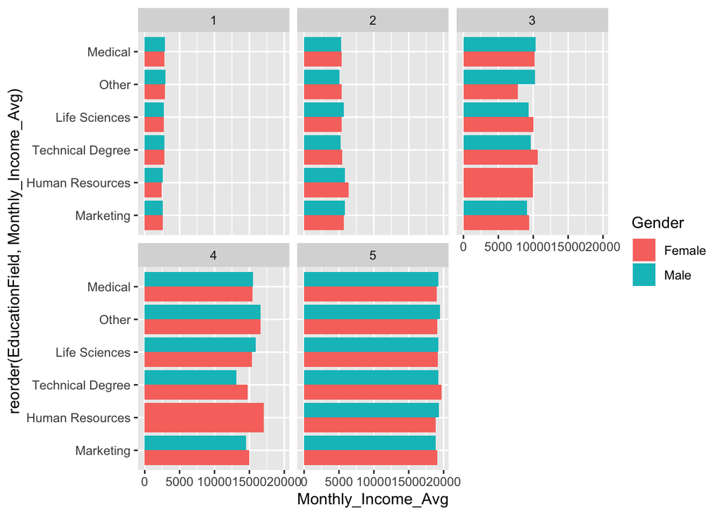

```r
gg<-ggplot(at_sum,aes(x=reorder(EducationField,Monthly_Income_Avg),
                      y=Monthly_Income_Avg,
                      fill=Gender))
## Bar plot, with unstacked (dodge)
 gg<-gg+geom_bar(stat="identity",position="dodge")
## Separate out by Job Level
gg<-gg+facet_wrap(~JobLevel)
## Change orientation to sideways
gg<-gg+coord_flip()
## Print
gg
```